# Correlation & Regression

Tehran Davis

10/17/2017

In this week’s class we covered **correlation** and **regression**. In what follows we will revisit the ideas from this week’s lecture making explicit callbacks to topics from slides and using an example from the text. The examples from this page involve R. For a tutorial on how to perform similar analyses in SPSS, please [check the appropriate video on the course Box Drive](https://uc.box.com/v/psych7014). Please note that this vignette assumes that you have the following packages installed and loaded in R: `cowplot`, `devtools`, `dplyr`, `ggplot2`, `lm.beta`, `plyr`, and `psych`.

```r
pacman::p_load(cowplot, devtools, dplyr, ggplot2, lm.beta, plyr, psych)
```

If you want to generate figures that have identical aesthetics as mine you will also need `ggthemr`. For the sake of identifying what functions come from each of these libraries I will be writing them in the `library::function` convention. For example, let’s install `ggthemr`:

```r
devtools::install_github('cttobin/ggthemr')
```

# The Relationship b/tw Stress and Health

**From Howell (Section 9.2):** Wagner, Compas, and Howell (1988) investigated the relationship between stress and mental health in first-year college students. Using a scale they developed to measure the frequency, perceived importance, and desirability of recent life events, they created a measure of negative events weighted by the reported frequency and the respondent’s subjective estimate of the impact of each event. This served as their measure of the subject’s perceived social and environmental stress. They also asked students to complete the Hopkins Symptom Checklist, assessing the presence or absence of 57 psychological symptoms.

This data (and most data mentioned in the text) can be accessed directly from Howell’s [companion website](https://www.uvm.edu/~dhowell/methods8/).

```r
# Data from Table 9.2 Howell
example <- read.table("https://www.uvm.edu/~dhowell/methods8/DataFiles/Tab9-2.dat", header=T)

summary(example)
```

```
##        ID            Stress         Symptoms        lnSymptoms
##  Min.   :  1.0   Min.   : 1.00   Min.   : 58.00   Min.   :4.060
##  1st Qu.: 27.5   1st Qu.:12.50   1st Qu.: 78.00   1st Qu.:4.357
##  Median : 54.0   Median :20.00   Median : 88.00   Median :4.477
##  Mean   : 54.0   Mean   :21.29   Mean   : 90.33   Mean   :4.483
##  3rd Qu.: 80.5   3rd Qu.:29.50   3rd Qu.:100.50   3rd Qu.:4.610
##  Max.   :107.0   Max.   :58.00   Max.   :147.00   Max.   :4.990
```

# Testing our assumptions

Here we are interested in the relationship between perceived **Stress** (as measured on a scale factors the number and impact of negative life events) and the presence of psychological **Symptoms**. As with any other parametric analysis, we first need to see if our data adheres to the assumptions of **normality** and **homogeniety of varience**. We can use the tools we’ve been employing for the last few weeks test these assumptions:

First **Stress**:

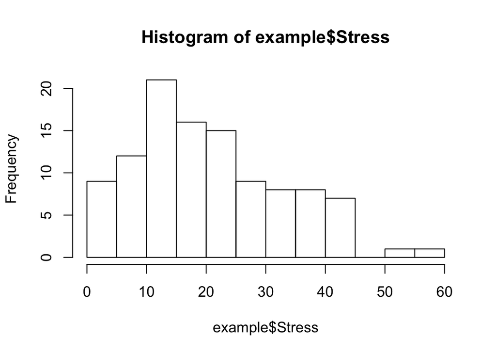

```r
hist(example$Stress,breaks = 10)
```

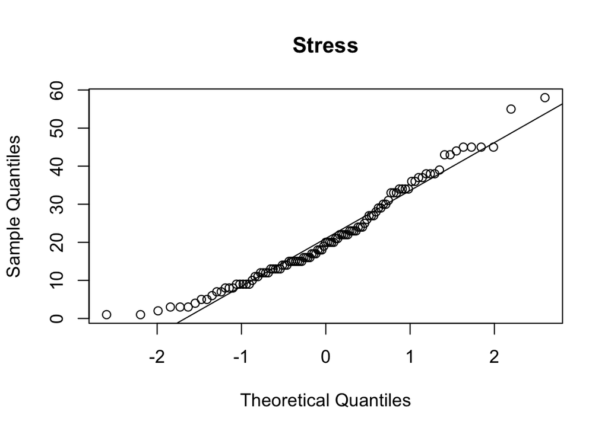

```r
qqnorm(example$Stress,main = "Stress");qqline(example$Stress)
```

```r
psych::describe(example$Stress)
```

```
##    vars   n  mean    sd median trimmed   mad min max range skew kurtosis
## X1    1 107 21.29 12.49     20   20.49 11.86   1  58    57 0.62    -0.19
##      se
## X1 1.21
```

```r
shapiro.test(example$Stress) # see Field (2014), Sec 5.6.1
```

```
##
##  Shapiro-Wilk normality test
##
## data:  example$Stress
## W = 0.96009, p-value = 0.002709
```

Eyeballing the plots, our **Stress** measures look slightly skewed, but not egregiously so. This is confirmed by our obtained `skew` and `kurtosis` values. The final function `shapiro.test()` performs a Shapiro-Wilkes test ($W$) of normality by comparing our observed distribution against a theoretical normal. Here the null hypothesis is that the $observed == theoretical$, where $p < .05$ indicates that the observed distribution is *not normal*. Our obtained p-value confirms suggests the possibility that **Sress** measures deviate from normal. However, as noted in the Field text (5.6.1) we need to be careful using the Shapiro-Wilkes test on large samples. Ultimately you need to make a judgment on whether or not all of the evidence available leads you to the conclusion of non-normality. In this case I would trust the normality of this data due to what I see in the Q-Q plot (very few large deviations from the normal line).

Turning to **Symptoms**:

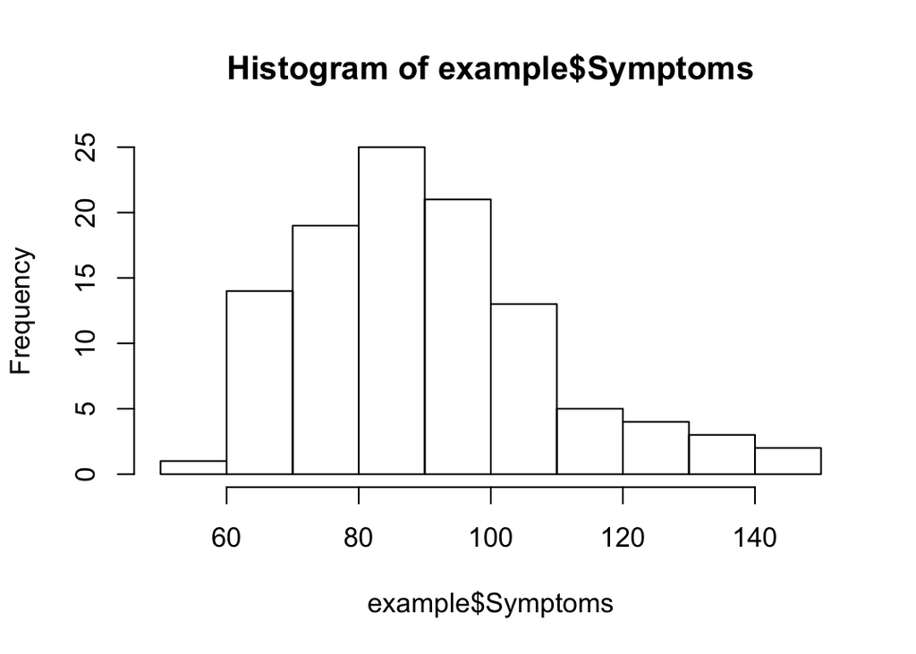

```r
hist(example$Symptoms,breaks = 10)
```

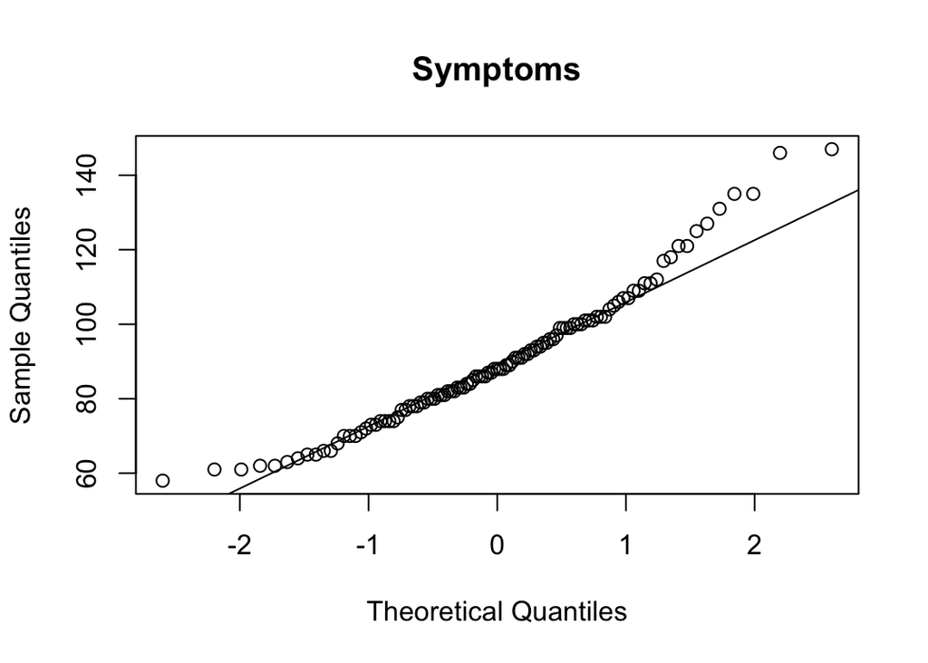

```r
qqnorm(example$Symptoms, main = "Symptoms");qqline(example$Symptoms)
```

```r
psych::describe(example$Symptoms)
```

```
##    vars   n  mean    sd median trimmed   mad min max range skew kurtosis
## X1    1 107 90.33 18.81     88   88.87 17.79  58 147    89 0.74     0.45
##      se
## X1 1.82
```

```r
shapiro.test(example$Symptoms)
```

```
##
##  Shapiro-Wilk normality test
##
## data:  example$Symptoms
## W = 0.95918, p-value = 0.00232
```

**Symptoms** does not pass either the eyeball or the Shapiro-Wilkes tests. These data are positively skewed. One way of dealing with non-normal data is by performing a logarithmic transformation (see Field, 5.8). This has already been performed for this data, **lnSymptoms** is a natural logarithmic transform of **Symptoms**. With your own data, this can be accomplished quite simply in R by using the `log()` function like so:

```r
log(example$Symptoms)
```

After the transformation, **lnSymptoms**:

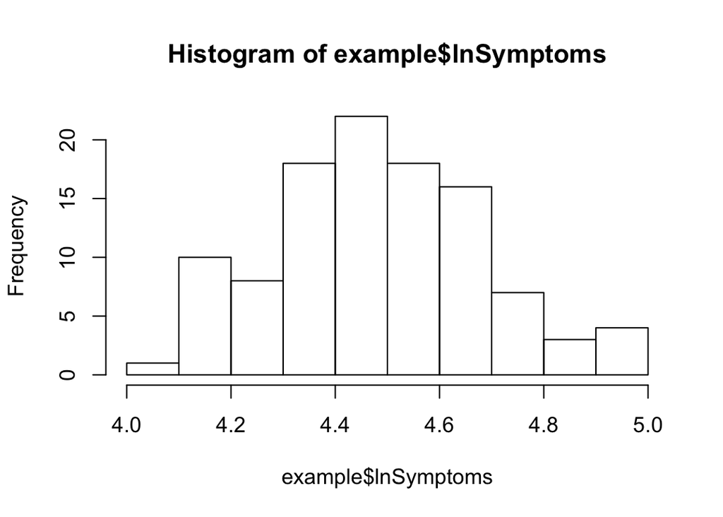

```r
hist(example$lnSymptoms,breaks = 10)
```

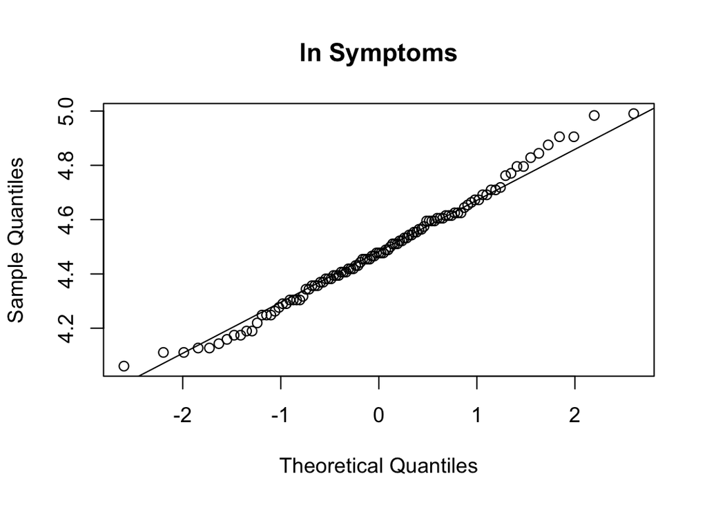

```r
qqnorm(example$lnSymptoms, main = "ln Symptoms");qqline(example$lnSymptoms)
```

```r
psych::describe(example$lnSymptoms)
```

```
##    vars   n mean  sd median trimmed  mad  min  max range skew kurtosis
## X1    1 107 4.48 0.2   4.48    4.48 0.19 4.06 4.99  0.93 0.21    -0.28
##      se
## X1 0.02
```

```r
shapiro.test(example$lnSymptoms)
```

```
##
##  Shapiro-Wilk normality test
##
## data:  example$lnSymptoms
## W = 0.98903, p-value = 0.5373
```

This looks much better.

# Plotting the data

One of the first things that you should do is plot your data. Plotting gives you a sense of what is going on with your data. In fact, **YOU SHOULD NEVER TAKE A TEST RESULT AT FACE VALUE WITHOUT FIRST LOOKING AT YOUR DATA!!** Beware of [Anscombe’s quartet](https://en.wikipedia.org/wiki/Anscombe%27s_quartet)!

Here we are using `ggplot2` to perform our plots. I’m also using `ggthemr` to tweak the look of the plots. We typically use a scatter-plot when plotting correlation data. To accomplish this using `ggplot2` we invoke the `geom_point()` function. Recall that a primer on building plots in `ggplot2` by yours truly may be found [here](https://tehjespah.github.io/teaching/PSYC7014/LevelingUp/PlottingData/bars_and_boxplots/) (including links to more comprehensive guides).

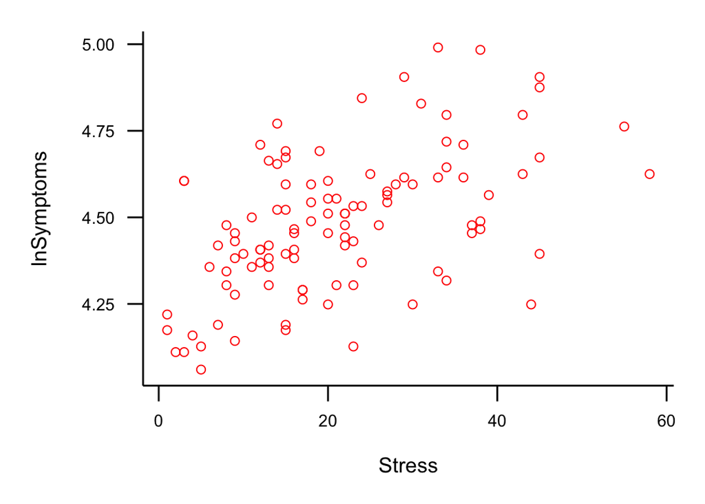

```r
# load in TJD custom ggthemr themes:
source('https://raw.githubusercontent.com/tehjespah/tehjespah.github.io/master/teaching/PSYC7014/TJDsourceFiles/customGGthemr.R')

ggthemr::ggthemr(webUC,layout = "clean", spacing = 3)

p <- ggplot2::ggplot(data = example, aes(x=Stress, y=lnSymptoms)) +
  # plot each data point as a small red open circle
  geom_point(colour = "red", size = 2, shape = 1)
show(p)
```

This plot suggests there may be interesting trends in our data. Now that we’ve plotted our data, we can move on to the statistical tests.

# Covariance and Correlation

Both the Howell and Field texts offer excellent overviews of **covariance** and **correlation** so won’t go into too much depth here. Briefly, let’s make a few connections to ideas that we’ve already encountered.

## Covariance

Recall that **variance** may be calculated as: $s_{x}^{2}=\frac{\sum \left ( x_{i}-\bar{X} \right )^{2}}{n-1}$

Where the numerator is the sum of squared differences from each score to the sample mean, and the denominator is our degrees of freedom.

Variance tells us to what degree scores in a particular sample variable deviate from its mean. With this in mind, **covarience** is a statement about the degree to which two sampled variables deviate from their respective means. Consider we have sampled two measures, *X* & *Y* from a population. When addressing the degree to which *X* and *Y* co-vary, we are asking the question: “To what degree and in what direction does *Y* move away from its mean as *X* moves from its mean?”

As such, the formula for covariance is simply an extension of the formula for variance that we already know:
$$s_{xy}=\frac{\sum \left ( x_{i}-\bar{X} \right )\left ( y_{i}-\bar{Y} \right )}{n-1}$$

So, in order to calculate the covariance we need the calculate the sum of the cross-product of the sum of squared differences of our two variables (*X* = **Stress**; *Y* = **lnSymptoms**) and divide that number by of degrees of freedom. We could go about the business of calculating this “by hand”:

```r
# N = number of rows in data frame
N <- nrow(example)


#mean Stress:
meanX <- mean(example$Stress)

# and same for lnSymptoms:
meanY <- mean(example$lnSymptoms)

# plug these values into our equation:

# sum of cross product
numerator <- sum((example$Stress-meanX)*(example$lnSymptoms-meanY))

# degrees of freedom
denominator <- (N-1)

# covariance:
covXY <- (numerator/denominator) %>% print()
```

```
## [1] 1.336434
```

The covariance of Stress and lnSymptoms is **1.336**.

Alternatively, covariance may be calculated quickly in `R` using the `cov` function:

```r
cov(example$Stress, example$lnSymptoms)
```

```
## [1] 1.336434
```

## Correlation

It may be tempting to calculate our **covariance** and stop there, but covariance is a limited measure. What I mean by this is that covarience indexes the degree of relationship between two specific variables, but doesn’t allow for more general comparison across situations. For a quick example, lets multiply both **Stress** and **lnSymptoms** by two. In R, (assuming all columns are `numerics`) we can accomplish this by multiplying the entire data frame by 2:

```r
example.by2 <- example * 2
head(example.by2)
```

```
##   ID Stress Symptoms lnSymptoms
## 1  2     60      198   9.190240
## 2  4     54      188   9.086590
## 3  6     18      160   8.764054
## 4  8     40      140   8.496990
## 5 10      6      200   9.210340
## 6 12     30      218   9.382696
```

We would like to think that multiplying every value by a constant should have no effect on our general interpretation of the relationships in our data as the overall relationship in our data remain the same. To help make this apparent, let’s imagine that I weigh 200 lbs (yea… imagine) and my wife weighs 100 lbs. So I weigh twice as much as my wife. Over the next year we both go on a binge fest and both double our respective weights—I’m now 400 lbs and my wife is 200 lbs. I still weigh twice as much as my wife. Coincidentally the fact that relationships remain unchanged in spite of these sorts of mathematical transformations is why we could perform the natural logarithmic transform earlier and not feel too guilty.

Well what happens when I get the covariance of my `by2` data?:

```r
cov(example.by2$Stress,example.by2$lnSymptoms)
```

```
## [1] 5.345735
```

**The covariance changes!!** This is a problem, and is why, in order to usefully convey this data we report the **correlation**. The correlation is a *standardized* covariance.

The unit of measurement we’ll use for standardization is the standard deviation. We can standardize the covariance in one of two ways:

1. Standardize our variables (into z-scores) and then calculate the covariance:
$$r_{xy}=\frac{\sum z_{x}z_{y}}{n-1}$$

```r
zX <- scale(example$Stress)
zY <- scale(example$lnSymptoms)

corXY <- (sum(zX*zY) / (N-1)) %>% print()
```

```
## [1] 0.5286565
```

or

2. Calculate the covariance and standardize it (by dividing by the product of the standard deviation):
$$r_{xy}=\frac{\sum \left ( x_{i}-\bar{X} \right )\left ( y_{i}-\bar{Y} \right )}{(n-1)s_{x}s_{y}}$$

```r
# get SD of X and Y:
sdX <- sd(example$Stress)
sdY <- sd(example$lnSymptoms)

# using the covXY calculated above:
covXY / (sdX*sdY)
```

```
## [1] 0.5286565
```

Again, in `R` we don’t need to do this by hand, there are in fact several functions. A more comprehensive look can be found in Field 6.5.3. The simplest function is `cor()`, with outputs the correlation as a single value. However, I prefer to use `cor.test()` as it tend to provides the most immediately useful data. You can input your data into this function in two ways:

```r
cor.test(example$Stress,example$lnSymptoms)
```

or

```r
cor.test(~Stress+lnSymptoms,data = example)
```

```
##
##  Pearson's product-moment correlation
##
## data:  Stress and lnSymptoms
## t = 6.3818, df = 105, p-value = 4.827e-09
## alternative hypothesis: true correlation is not equal to 0
## 95 percent confidence interval:
##  0.3765970 0.6529758
## sample estimates:
##       cor
## 0.5286565
```

I prefer the latter as it uses formula notation (recall similar cases with `t.test()` and `car::leveneTest()`), which is the sort of notation we will use for regression and later ANOVA. Finally, if you don’t want all the additional gobble-dee-gook from `cor.test` you can simply attach `$estimate` to the end of either the function or object like so (for now, trust me, but see section below on getting the attributes of an object ):

```r
cor.test(~Stress+lnSymptoms,data = example)$estimate
```

```
##       cor
## 0.5286565
```

Our correlation is expressed in terms of the **Pearson’s product-moment correlation coefficient** (or $r$, for short). Here $r$ = .529.

Coincidentally, returning to our problematic transformed data, we find that the obtained $r$ is identical:

```r
cor.test(~Stress+lnSymptoms,data = example.by2)
```

```
##
##  Pearson's product-moment correlation
##
## data:  Stress and lnSymptoms
## t = 6.3818, df = 105, p-value = 4.827e-09
## alternative hypothesis: true correlation is not equal to 0
## 95 percent confidence interval:
##  0.3765970 0.6529758
## sample estimates:
##       cor
## 0.5286565
```

Note that when our sample size is small we may need to adjust $r$. This is because the sampling distribution of $r$ is not normally distributed.

The formula for this adjustment is: $r_{adj}=\sqrt{1-\frac{\sum \left (1-r^2 \right )\left ( n-1 \right )}{n-2}}$

For now, we can calculate this by hand, but later we will see that it will be provided by another function (or at least its squared value will).

```r
# Pearson's r:
rXY <- cor.test(~Stress+lnSymptoms,data = example)$estimate

# adjusted r:
rXYadj <- sqrt(1-((1-rXY^2)*(N-1)/(N-2))) %>% print()
```

```
##      cor
## 0.522126
```

## Sigfnificance testing $r$

Finally it may be useful to perform tests of significance on $r$. Typically, there are two types of tests that we perform, (1) a test of the observed $r$ to $r=0$, and (2) a test of the difference between two $r$ values. Regarding the first case, the test that the observed correlation is different from 0, Howell correctly notes the following (Section 9.11): - “a test on b is equivalent to a test on r in the one-predictor case we are discussing in this chapter. If it is true that $X$ and $Y$ are related, then it must also be true that $Y$ varies with $X$—that is, that the slope is nonzero. This suggests that a test on $b$ (beta coefficient) will produce the same answer as a test on $r$, and we could dispense with a test for $b$ altogether.”

The reverse is also true. In the single predictor case, if one has a test of $b$ this obviates the need to run an independent test of $r$. As you will see below, we indeed do have a simple test that gives us the significance of the beta coefficient, $b$.

In the second case, the difference between $r$ values, we may invoke the `paired.r()` function from the `psych` package. Using the $r$ values from the example in Section 9.11 of the Howell text, “Testing the Difference Between Two Independent $r$s”:

```r
psych::paired.r(xy = .50, xz = .40,n = 53,n2 = 53,twotailed = T)
```

```
## Call: psych::paired.r(xy = 0.5, xz = 0.4, n = 53, n2 = 53, twotailed = T)
## [1] "test of difference between two independent correlations"
## z = 0.63  With probability =  0.53
```

This output tells us the resulting Fisher $z$ score and corresponding probability.

# Fitting the data to a model

As social scientists, we are not only concerned with observation, but also with explanation. Measures of correlation provide us with the former; we use regression methods to build models in service of the latter. Again both the Field and Howell texts provide excellent overviews of regression, so I won’t repeat much of what they say here.

For the purposes of this vignette (and course) we will limit ourselves to linear regression, that is describing a line that best fits our data. By “fit” we mean a line than when compared to our observed data minimizes our squared residuals.

To perform a linear regression we may call upon the `lm()` function. This function uses formula notation `outcome variable ~ predictor variable(s)`. A simple regression has a single predictor. More often in our analyses we are concerned with the relative effects of multiple predictors, but this is multiple regression and saved for the Spring course. Here, we may be interested in the degree to which perceived **Stress** contributes to the number of **lnSymptons**, or using formula terminology: “How do lnSymptoms (outcome) vary as a function of Stress (predictor)”. This is represented in R as `example$lnSymptoms~example$Stress`

## Linear models in R

Our model assigned to `example.model`:

```r
example.model <- lm(example$lnSymptoms~example$Stress)
print(example.model)
```

```
##
## Call:
## lm(formula = example$lnSymptoms ~ example$Stress)
##
## Coefficients:
##    (Intercept)  example$Stress
##       4.300537        0.008565
```

While this output only gives us our coefficients (intercept and slope of our line), our object `example.model` has the class `lm`. This simply means that R understands that this object is storing a linear model. Hiding behind this spartan output is a multitude of info that may be accessed via its `attributes` or it may be thrown into other functions for additional info and analysis.

## Attributes of class `lm`:

As I mentioned above, `lm` objects contain various attributes that may be accessed using the names convention, `$nameOfAttribute`.

For example, returning to the `example.model` object we created above, we may get a glimpse of its attributes by:

```r
attributes(example.model)
```

```
## $names
##  [1] "coefficients"  "residuals"     "effects"       "rank"
##  [5] "fitted.values" "assign"        "qr"            "df.residual"
##  [9] "xlevels"       "call"          "terms"         "model"
##
## $class
## [1] "lm"
```

This command tells us the names of several attributes (values) that are stored in `example.model`. Typically we are interested in the `$coefficients`, `fitted.values` (aka *predicted values*), and `$residuals`. Recall that in our model `fitted.values` are the predicted values of **lnSymptoms** for each value of **Stress**, that is those values that fall along the line of best fit. `residuals` are the difference between our observed values of **lnSymptoms** and those predicted by the model. Mathematically `example.model$residuals` is equivalent to:

```r
example$lnSymptoms - example.model$fitted.values
```

## Testing the residuals:

An important assumption test for our model is that the residuals are normally distributed. In fact some argue that this is more important than than having normal distributions in the raw data itself. Quickly, we can test this using the regular methods:

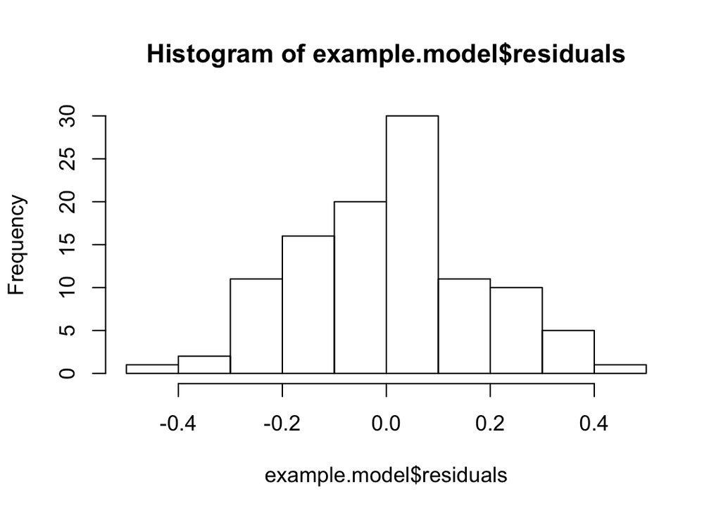

```r
hist(example.model$residuals,breaks = 10)
```

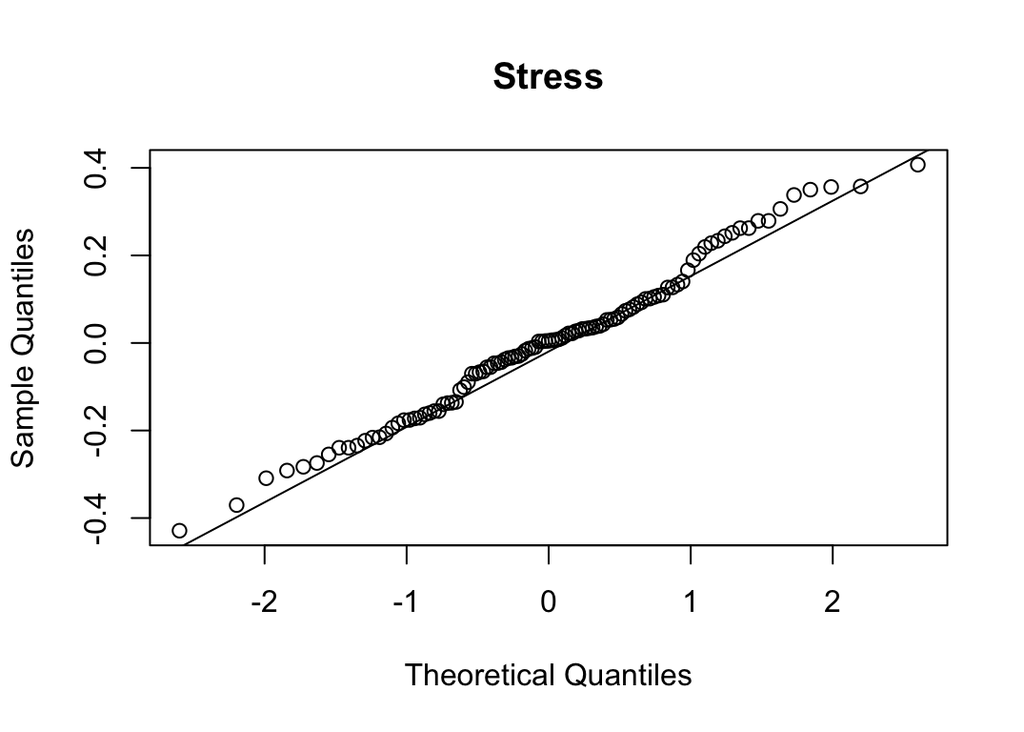

```r
qqnorm(example.model$residuals,main = "Stress")
qqline(example.model$residuals)
```

```r
psych::describe(example.model$residuals)
```

```
##    vars   n mean   sd median trimmed  mad   min  max range skew kurtosis
## X1    1 107    0 0.17      0       0 0.15 -0.43 0.41  0.84 0.12    -0.27
##      se
## X1 0.02
```

```r
shapiro.test(example.model$residuals) # see Field (2014), Sec 5.6.1
```

```
##
##  Shapiro-Wilk normality test
##
## data:  example.model$residuals
## W = 0.9876, p-value = 0.429
```

The residuals pass the test.

## Using your `lm` object with other functions

As I mentioned above you may also use `lm` objects with other functions. For example, for our model `example.model`:

```r
plot(example.model)
```

produces a host of successive plots, including a plot of “Residuals v. Fitted”, A Q-Q plot that includes possible outliers, and a leverage plot. The last is outside of the scope of this course, but may be useful for you to remember in the Spring!

A useful call for our present purposes is:

```r
summary(example.model)
```

[output not shown]

which provides us with info about the coefficients, their standard error, *t*-scores, and corresponding p-values (Pr>|t|). It also provides us with our $r^2$ and adjusted $r_{adj}^2$ (which corresponds to our $r$ and $r_{adj}$ from above).

Coincidentally we can also call the individual attributes of this summary as well:

```r
summary(example.model) %>% attributes()
```

```
## $names
##  [1] "call"          "terms"         "residuals"     "coefficients"
##  [5] "aliased"       "sigma"         "df"            "r.squared"
##  [9] "adj.r.squared" "fstatistic"    "cov.unscaled"
##
## $class
## [1] "summary.lm"
```

```r
summary(example.model)$coefficients
```

```
##                   Estimate  Std. Error    t value      Pr(>|t|)
## (Intercept)    4.300536618 0.033087547 129.974478 8.085268e-118
## example$Stress 0.008564802 0.001342063   6.381819  4.827486e-09
```

We’ll return to each of these later, but first let’s return to our plot:

## Plotting the regression line

It’s useful practice to plot the regression line. In fact, I would typically recommend doing this at the outset of the analysis (way back at the beginning) but we had a few things to cover make this step clear. To add a simple regression line to our previous plot we can use the `geom_smooth()` function:

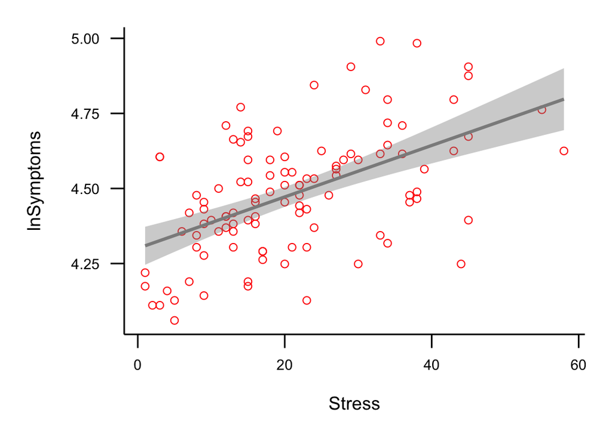

```r
# previous plot above
p <- ggplot2::ggplot(data = example, aes(x=Stress, y=lnSymptoms)) +
  # plot each data point as a small red open circle
  geom_point(colour = "red", size = 2, shape = 1)

#adding the regression line
p <- p + geom_smooth(method=lm, level = 0.95)
show(p)
```

The shaded ribbon around the line of regression represents the 95% CI of the estimate at each value of the predictor. The size of the CI may be adjusted by using the `level` parameter in `geom_smooth()`.

From this plot it becomes apparent that the model coefficients obtained above represent the values of the slope and intercept of the regression line.

- The beta coefficient conveys the *slope* of the line—unit change in outcome per unit change in predictor. Typically this is expressed as *b* in text or **B** in SPSS. In `R` output, the beta estimate is tied to the name of the corresponding predictor variable. In our case that’s `example$Stress`.
- The **intercept** tells us what the value of the outcome would be if the predictor was 0. In most instances the intercept is not terribly useful. For example if you were looking at the relationship between height and weight it would make no sense to concern yourself with instances where height is absolutely 0. Obviously, a caveat here is if the value 0 is meaningful for your analysis. For example perhaps you are looking at depression as a function of alcohol consumption and want to explicitly say something about people that have never had a single drink in their life. One way of making a meaningless intercept meaningful is by centering your data (subtracting every value of your predictor from a constant). For example, if you center around the mean, the intercept will tell you the predicted value of the outcome variable at the mean value of the predictor.

Just for giggles, lets plot our mean-centered data

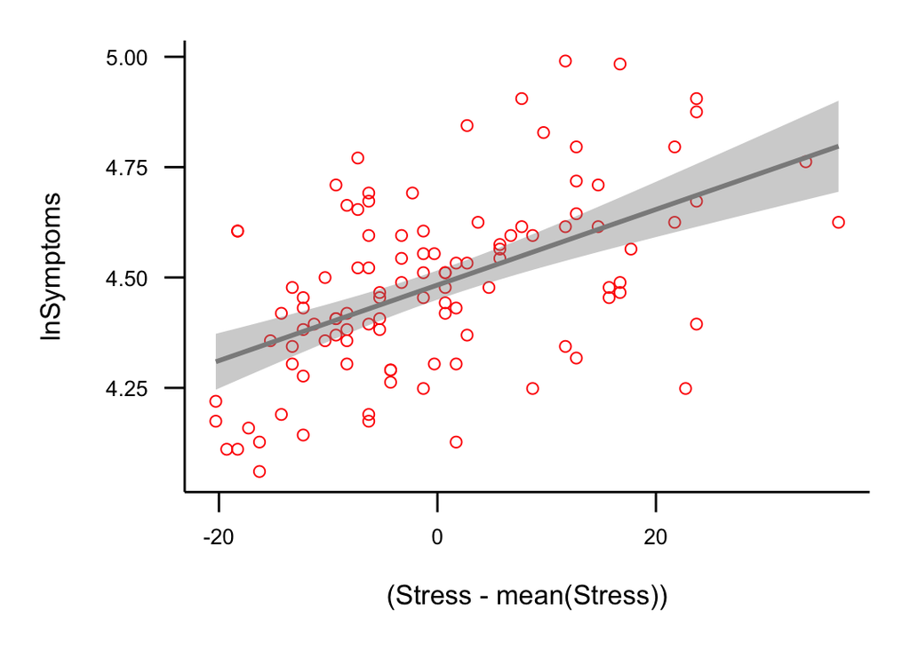

```r
ggplot2::ggplot(data = example, aes(x=(Stress-mean(Stress)), y=lnSymptoms)) +
  # plot each data point as a small red open circle
  geom_point(colour = "red", size = 2, shape = 1) +
  geom_smooth(method=lm, level = .95)
```

as you can see slope doesn’t change, but the values become centered around the intercept.

## A note on degrees of freedom of our model

The general equation for calculating the requisite degrees of freedom of a model is $n-k$ where $n$ is the number of observations (or later conditions) and $k$ is the number of parameters that are required to be known for the calculation.

Recall how we calculate variance / standard deviation. We take the sum of the squared deviations from the *mean* $\sum(X-\bar{X})$ and divide by $(n-1)$. Remember that we are subtracting that 1 because in order to calculate the variance we must keep one thing constant, the **mean**. In this case the **mean** is our parameter that must be known in order to calculate the variance.

We can now ask the question “what must be known in order to derive the line of best fit?”, or more simply what must one know in order to create a particular line. We must know **both** the line’s **slope** and its **intercept**. Knowing slope alone leads to the indeterminism presented in Fig A (identical slopes, infinitely-many intercepts), intercept alone leads to indeterminism presented in Fig B (identical intercept, infinitely-many slopes). We need **both** to define a particular line. Just like the **mean** above, these are the two parameters that must be *locked-in* to derive our model.

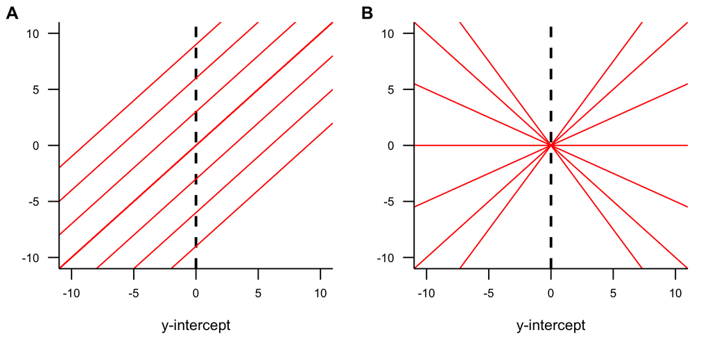

A simple way of restating this is that your model degrees of freedom are the:
$$number\space of\space observations\space (n) - number\space of\space predictors\space (\beta) - number\space of\space intercepts$$

For simple regression we have 1 predictor and 1 intercept so our degrees of freedom are $n-k$; where $k=2$. However, in your future **there be be dragons**… models that may have multiple predictors and multiple intercepts (multiple regression, mixed effects / multi-level models, etc).

## Interpreting the output

With our plot in hand, we can return to our `summary(example.model)` output:

- **Call**: tells us the formula we originally input for this model
- **Residuals**: descriptive stats of the residuals
- **Coefficients**: provides the estimated values, standard error of the estimates, and NHST of the intercept and beta coefficient. In both cases the null hypothesis is Estimate = 0. Again for the intercept this may or may not be useful. For example you might use it to test whether people who haven’t had a single drink of alcohol have no depression at all. The test of `beta` tests against the null hypothesis of zero correlation (relationship). All tests are conducted provided the t-value on $n-k$ degrees of freedom (see next bullet point)
- **Residual standard error**: This is calculated by first getting the sum of the squared residuals and dividing that number by the degrees of freedom of the model. In this case the df equals the number of total observations (107) minus the number of parameters ($k$) that were calculated by the model in order to generate the predicted values (2). This may be interpreted as a measure of goodness of fit of the model, and perhaps more importantly its predictive value (see Howell 9.7).
- **Multiple R-squared** and **Adjusted R-squared**: The **coefficient of determination** calculated from $r$ or $r_{adj}$. $r^2$ tells us the degree to which our model accounts for observed variance in the observed outcomes. On was to think about this is, to what degree does variation in our predictor explain the observed variation in our outcomes. More on this below.
- Finally, this output gives is the resulting $F$-ratio and corresponding $df$ for an $F$-test. This is a significance test for our $r^2$. Does our model explain a significant amount of the variance?

# The coeff. of determination as index of explanatory value

Here we may turn to our (a little bit longer than expected) digression in class involving J.S. Mill and *exact* and *inexact* sciences. One philosophical conceit is that we can never really empirically observe causes, but only effects. That is, I can never truly observe that one billiard ball *caused* another to move, I can only say with a high degree of certainty that I observed the first billiard ball striking the second and subsequently the second moved at a particular velocity. In order to deal with this epistemological crisis (how can you really ever know anything!!!) we build explanatory models. The degree to which our model is able to account for the range of our previous observations tells us how useful our model parameters (predictors) are in explaining a phenomenon in question.

For example, to explain what I observe about the contact and subsequent motion of billiard balls I might build a model that takes into account the mass and velocity (speed and direction) of the first ball, the mass and velocity of the second ball and the point and angle of contact. Presuming I use these as predictors, I can account with varying degrees of success the heading and direction of the balls, or the *outcome*. In fact, in this example, I’m likely to be very successful in describing most, **but not all** observed outcomes. That is, there are some variations in the outcomes that just using these parameters does not result in a successful account. I can refine my *billiard contact model* to include things like the friction caused from the felt, the force of gravity, the angle of the table top, etc., and it’s likely the case that with each new predictor my model becomes better. However at some point I begin to reach diminishing returns (see over-fitting next semester).

This is why physics *appears* to be an exact science (well, really mechanical physics at least). They’ve had centuries to develop and refine their models about the mechanical workings of our very local corner of the universe to the point that these models are able to account for a very high degree of variation in observed phenomena. These models typically have a very high $r^2$ and as such tend to have high predictive value. Which is why with some understanding of gravitational force, mass, and a few simple calculations, high school students all over country are able to do [this](https://www.youtube.com/watch?v=46CJmWlxfck) in their physics lab.

Indeed within some disciplines having an $r^2$ < .9 means you model isn’t good enough. Typically this is the case when the phenomenon under observation is not complex (hope that doesn’t offend). As you move away from physics and chemistry (or at least the low complexity phenomena under each discipline), the explanatory value of models tends to decrease. Here we are moving into inexact-science-land. Weather patterns, economies, ecosystems, and human behaviors are highly complex; in many cases in inordinate number of contributing factors may be present in an observed outcome. As a result degree of variation that these models may account for is typically diminished, especially in the social sciences. For example depending on the phenomena and sub-discipline, an $r^2$ of .3 might mean you’re cooking with gas! In fact, for some phenomena, a reported $r^2$ that is too high might be a cause for suspicion (“they weren’t so much cooking with gas so much as they were cooking the books”).

As a final note, its typically poor practice to get a significant $r^2$ and just stop there. Remember, this is just a claim that your model accounts for significantly more variation than 0%. If you were to have a model that accounted for 6% ($r^2 = .06$) of the variance but was significant ($p<.05$), you need to ask yourself whether that model is useful at all. It certainly has very little predictive value (I wouldn’t bet my life… or even a few bills on it predicting a future outcome), and its true explanatory value is quite questionable.

# Write up and presentaion

Our obtained results can be reported in several different ways. However, typically it’s best practice to report both the $beta$ coefficient with corresponding $t-test$; as well as the general statistics about the model including the $r^2$ and corresponding $F-test$. Prior to any reporting of the stats, you also need to articulate the structure of the model.

For example, with this data you may report it as:

> “To test this hypothesis the data were fit to a linear regression model with the number of psychological symptoms as the outcome and stress index as our predictor. The resulting model was significant [$r^2=.279; F(1,105)=40.73, p<.001$] and revealed a significant relationship between the index of stress and the number of psychologcial symptoms [$b=.009; t(105)=6.38, p<.001$].”

That said, in many circles it’s typical practice to report the *standardized* $beta$ coefficients ($\beta$). These are the $beta$ coefficients we would have obtained if we had initially converted both our *Stress* and *lnSymptom* values to $z$-scores. We can retroactively obtain these coefficients by using the `lm.beta()` function from the `lm.beta` package (duplicate names, confusing I know). We can then input an `lm` class objects into the `lm.beta()` function:

```r
lm.beta::lm.beta(example.model)
```

```
##
## Call:
## lm(formula = example$lnSymptoms ~ example$Stress)
##
## Standardized Coefficients::
##    (Intercept) example$Stress
##      0.0000000      0.5286565
```

```r
# or the entire summary of the model
lm.beta::lm.beta(example.model) %>% summary()
```

```
##
## Call:
## lm(formula = example$lnSymptoms ~ example$Stress)
##
## Residuals:
##      Min       1Q   Median       3Q      Max
## -0.42889 -0.13568  0.00478  0.09672  0.40726
##
## Coefficients:
##                Estimate Standardized Std. Error t value Pr(>|t|)
## (Intercept)    4.300537     0.000000   0.033088 129.974  < 2e-16 ***
## example$Stress 0.008565     0.528656   0.001342   6.382 4.83e-09 ***
## ---
## Signif. codes:  0 '***' 0.001 '**' 0.01 '*' 0.05 '.' 0.1 ' ' 1
##
## Residual standard error: 0.1726 on 105 degrees of freedom
## Multiple R-squared:  0.2795, Adjusted R-squared:  0.2726
## F-statistic: 40.73 on 1 and 105 DF,  p-value: 4.827e-09
```

**To be safe, its usually better to report your coefficients**: [$\beta =.529; t(105)=6.38, p<.001$]

# Advanced plotting

Depending on what info you are trying to convey, there are several ways of dressing up your plot. In this section we’ll cover three things that you can do with the plots above: - adding text information like $r^2$ and the equation of the regression line - placing two (or more) plots side-by-side - placing two sample (and regression lines) on the same plot

## adding text to the plot

Text may be added to a plot using the `annotate()` function in `ggplot2`. This function has several arguments: the type of annotation (typically `geom="text"`), the `x` position of the plot (measured in units of the x axis), the `y` position of the plot, the `label` or text that you want to add (in string form) and the whether or not `R` needs to parse the text. For simple text like “Hi my name is..” you don’t need parsing. For more complex text like some of what we will be doing (text that needs to be italicized, superscripts, etc) you need to set `parse=TRUE`. Finally you can adjust the size of the text.

We can create the necessary text for out plot by hand by simply adding these repective values in format that we construct. however, there are a few leaps and bounds that we need to do in order to format the text and plug in our values. For the same of simplicity just take this at face value for now, but feel free to follow-up in your free time to see exactly what is going on here:

```r
# putting together my equation, telling R
# to add superscripts and italics:
equation <- italic(y) == 4.301 + 0.009 %.% italic(x)*","~~italic(r)^2~"="~.280

# turn it into an expression for R to parse:
equation <- as.expression(equation) %>% as.character()
```

and now add it to my previous plot using `annotate()`

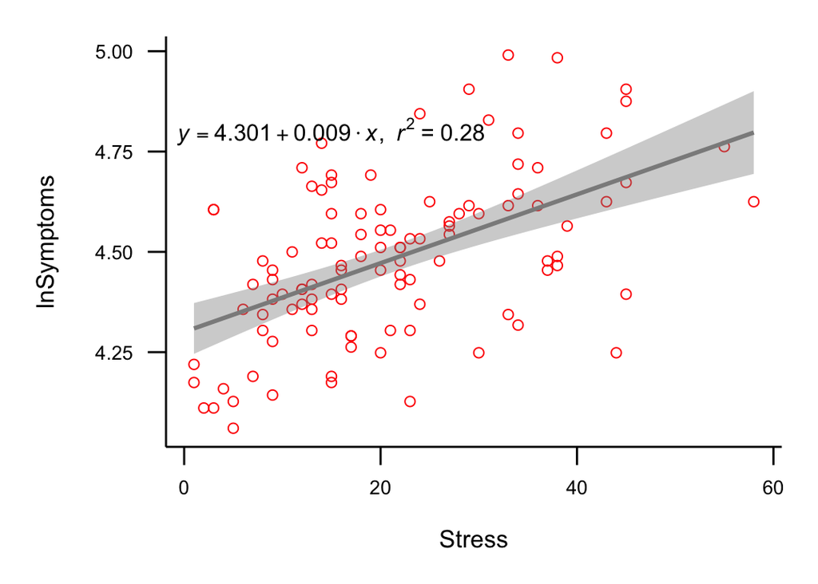

```r
# create scatter plot
p <- ggplot2::ggplot(data = example, aes(x=Stress, y=lnSymptoms)) +
  # plot each data point as a small red open circle
  geom_point(colour = "red", size = 2, shape = 1)

# adding the regression line
p <- p + geom_smooth(method=lm, level = 0.95)

# adding text
p <- p + annotate(geom = "text", x=15, y=4.8, label=equation, parse = T, size = 4)

show(p)
```

The other useful thing to remember is that you can access different parts of an `lm` class object using its attributes (see above). In this case we can call on various attributes of `example.model`. For example we can get the coefficients by:

```r
example.model$coefficients
```

```
##    (Intercept) example$Stress
##    4.300536618    0.008564802
```

we call also get them by using the `coef()` function:

```r
coef(example.model)
```

```
##    (Intercept) example$Stress
##    4.300536618    0.008564802
```

the same can be said about the $r^2$. It’s available from the summary model attributes:

```r
# list our attributes:
summary(example.model) %>% attributes()
```

```
## $names
##  [1] "call"          "terms"         "residuals"     "coefficients"
##  [5] "aliased"       "sigma"         "df"            "r.squared"
##  [9] "adj.r.squared" "fstatistic"    "cov.unscaled"
##
## $class
## [1] "summary.lm"
```

```r
#we want "r.squared":
summary(example.model)$r.squared
```

```
## [1] 0.2794776
```

knowing this we can actually create a function to do the above for us automatically (see I told you building you own functions would com in handy). True, there are a few things that we haven’t covered yet in the code, so feel free to look them up:

```r
# create a function called lm_eqn
lm_eqn = function(m) {

  l <- list(a = format(coef(m)[1], digits = 2),
      b = format(abs(coef(m)[2]), digits = 2),
      r2 = format(summary(m)$r.squared, digits = 3));

  if (coef(m)[2] >= 0)  {
    eq <- substitute(italic(y) == a + b %.% italic(x)*","~~italic(r)^2~"="~r2,l)
  } else {
    eq <- substitute(italic(y) == a - b %.% italic(x)*","~~italic(r)^2~"="~r2,l)
  }

  as.character(as.expression(eq));
}
```

after running the chunk above (or executing the function in to memory) you can just plug in you `lm` object into the function:

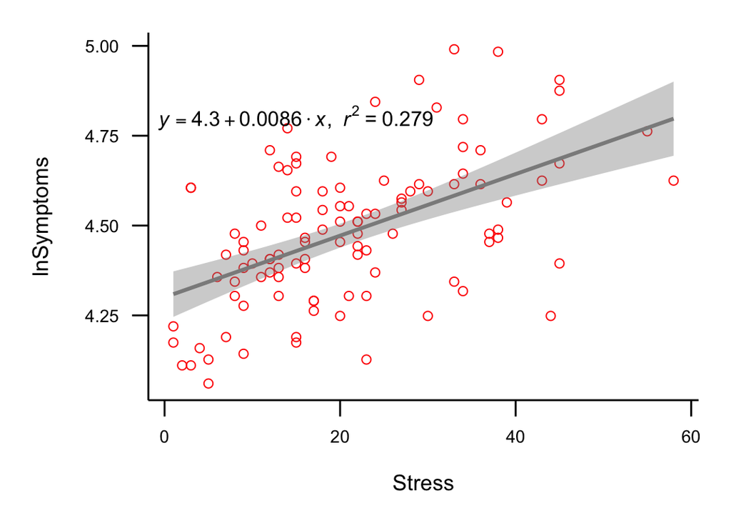

```r
# plug in the lm.model
equation <- lm_eqn(example.model)

# create scatter plot
p <- ggplot2::ggplot(data = example, aes(x=Stress, y=lnSymptoms)) +
  # plot each data point as a small red open circle
  geom_point(colour = "red", size = 2, shape = 1)

# adding the regression line
p <- p + geom_smooth(method=lm, level = 0.95)

# adding text
p <- p + annotate(geom = "text", x=15, y=4.8, label=equation, parse = T, size = 4)

show(p)
```

## Placing plots side-by-side in a grid

You can place two or more plots in a grid using the `plot_grid()` function from the `cowplot` library. You can check out an [intro to cowplot here](https://cran.r-project.org/web/packages/cowplot/vignettes/introduction.html). Indeed, `cowplot` does so much more than grid plotting! `cowplot` can be install from CRAN, so we can simply:

```r
pacman::p_load(cowplot)
```

The `plot.grid()` function has several arguments. For now, we’ll just focus on a few, including the *list of plots to include*, *labels for each plot*, and their *arrangement* specified in the number of rows and columns. For the purpose of this example and the next, let’s create a new data set that takes a look at the data above as broken down by men and women:

```r
# read in the data above:
example2 <- read.table("https://www.uvm.edu/~dhowell/methods8/DataFiles/Tab9-2.dat", header=T)

# create a gender vector of 57 women and 50 men:
gender <- c(rep("w",57),rep("m",50))

# randomize gender using sample
set.seed(1) # just so we randomize the same
gender <- sample(gender)

# add gender to our example 2 data.frame
example2 <- data.frame(example2,gender)
head(example2)
```

```
##   ID Stress Symptoms lnSymptoms gender
## 1  1     30       99   4.595120      w
## 2  2     27       94   4.543295      w
## 3  3      9       80   4.382027      m
## 4  4     20       70   4.248495      m
## 5  5      3      100   4.605170      w
## 6  6     15      109   4.691348      m
```

Now that we have our data set we can separate out women’s data from men’s data. We’ve done this before using the `filter` function in `dplyr`. Another way is to use the `subset()` function:

```r
womenData <- subset(example2, gender=="w")
menData <- subset(example2,gender=="m")
```

now we can create two separate plots and grid them side by side.

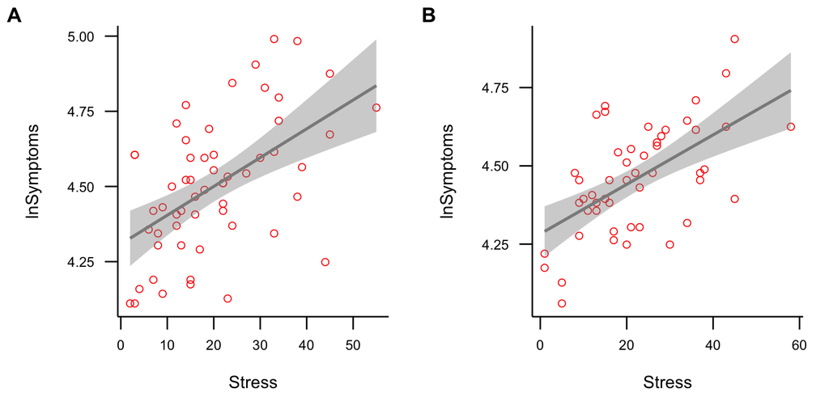

```r
# women plot
wPlot <- ggplot2::ggplot(data = womenData, aes(x=Stress, y=lnSymptoms)) +
  # plot each data point as a small red open circle
  geom_point(colour = "red", size = 2, shape = 1) +
  geom_smooth(method=lm, level = 0.95)

# men plot
mPlot <- ggplot2::ggplot(data = menData, aes(x=Stress, y=lnSymptoms)) +
  # plot each data point as a small red open circle
  geom_point(colour = "red", size = 2, shape = 1) +
  geom_smooth(method=lm, level = 0.95)

# plot them side by side:
plot_grid(wPlot,mPlot, labels = c("A","B"), ncol = 2)
```

Note here I’ve labeled the women’s plot “A” and men’s plot “B”. I can label these whatever my hear desires, though typical convention is lettering. I can also stack them vertically by specifying rows instead of columns:

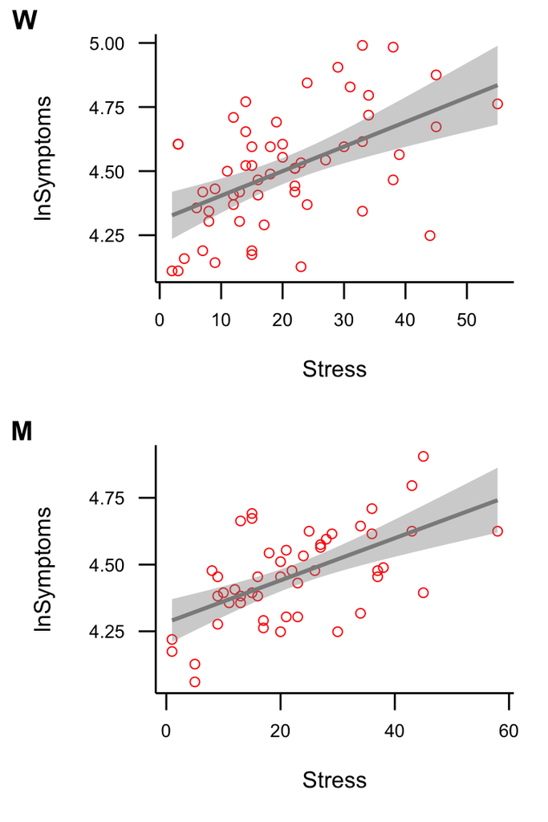

```r
plot_grid(wPlot,mPlot, labels = c("W","M"), nrow = 2)
```

## Two series on the same damn plot

*on the same damn plot, on the same damn plot…*

For our last trick, let’s plot both men and women’s data on the same figure. This can be accomplished by using our original `example2` data frame and specifying different shape, colors, and regression lines as a function of gender:

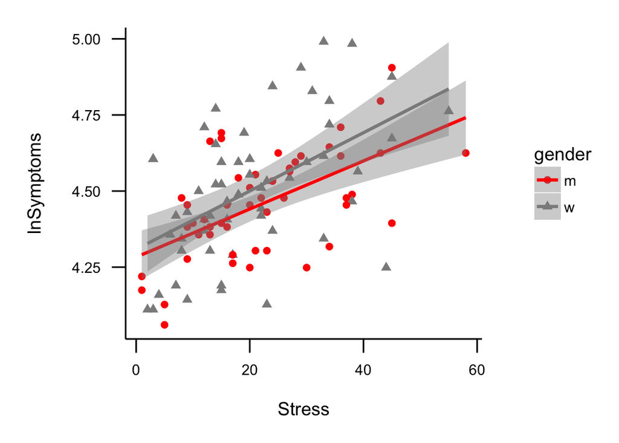

```r
# add color and shape arguments here. These calls state that
# difference shapes and colors should be used for each level of gender:
bothPlot <- ggplot2::ggplot(data = example2, aes(x=Stress, y=lnSymptoms, shape=gender,color=gender)) +
  # only need to specify size here:
  geom_point(size = 2) +
  geom_smooth(method=lm, level = 0.95)

show(bothPlot)
```